# Stupidest sampler presentation

## And there we are there

at gates of Bayes’ theorem.

\[ P(H|d)=\frac{P(d|H)P(H)}{P(d)}\]

If we have two hypotheses like now, we can say that it is

\[ P(H_1|d)=\frac{P(d|H_1)P(H_1)}{P(d|H_1)P(H_1)+P(d|H_2)P(H_2)}\] \[ P(H_2|d)=\frac{P(d|H_2)P(H_2)}{P(d|H_1)P(H_1)+P(d|H_2)P(H_2)}\]

## See?

Numerators are different, denominators are the same. Numerators are what makes the difference. \[ P(H_1|d)=\frac{P(d|H_1)P(H_1)}{P(d|H_1)P(H_1)+P(d|H_2)P(H_2)}\] \[ P(H_2|d)=\frac{P(d|H_2)P(H_2)}{P(d|H_1)P(H_1)+P(d|H_2)P(H_2)}\] ## Updating Integrates information from multiple domains. (Your friend who exposes you to the cointosses might be a cheater an you know it.)

```r
l1<-dbinom(3,4,0.5)*0.1 #numerators
l2<-dbinom(3,4,0.8)*0.9
p1<-l1/(l1+l2) #divide them with a common denominator
p2<-l2/(l1+l2)
```

```
##         p1         p2
## 0.06350981 0.93649019
```

## After the additional toss of “tails”

```r
l1<-dbinom(0,1,0.5)*p1
l2<-dbinom(0,1,0.8)*p2
p1<-l1/(l1+l2)
p2<-l2/(l1+l2)
```

```
##        p1        p2
## 0.1449645 0.8550355
```

## Any so called “posterior probability”

can be fed into the “Bayes’ theorem” or rather the “hypothesis credibility machine” as “prior probability” before the new data are observed. And the new data then update the hypotheses probabilities in a nice formal unambiguous way. Bayesian statistics is the best formal epistemology that we have so far.

## The “prior” for short was always there

```r
l1<-dbinom(3,4,0.5)*0.5 #numerators
l2<-dbinom(3,4,0.8)*0.5

p1<-l1/(l1+l2) #divide by their sum
p2<-l2/(l1+l2)
```

```
##        p1        p2
## 0.3790176 0.6209824
```

## Plus the additional “tails”

```r
l1<-dbinom(0,1,0.5)*p1
l2<-dbinom(0,1,0.8)*p2
p1<-l1/(l1+l2)
p2<-l2/(l1+l2)
```

```
##        p1        p2
## 0.6040982 0.3959018
```

## For the sake of absurdity:

by observation

```r
#First toss (heads)
l1<-dbinom(1,1,0.5)*0.5
l2<-dbinom(1,1,0.8)*0.5
p1<-l1/(l1+l2)
p2<-l2/(l1+l2)
```

```
##        p1        p2
## 0.3846154 0.6153846
```

## For the sake of absurdity:

by observation

```r
#Second toss (tails)
l1<-dbinom(0,1,0.5)*p1
l2<-dbinom(0,1,0.8)*p2
p1<-l1/(l1+l2)
p2<-l2/(l1+l2)
```

```
##        p1        p2
## 0.6097561 0.3902439
```

## For the sake of absurdity:

by observation

```r
#Third toss (heads)
l1<-dbinom(1,1,0.5)*p1
l2<-dbinom(1,1,0.8)*p2
p1<-l1/(l1+l2)
p2<-l2/(l1+l2)
```

```
##        p1        p2
## 0.4940711 0.5059289
```

## For the sake of absurdity:

by observation

```r
#Fourth toss (heads)
l1<-dbinom(1,1,0.5)*p1
l2<-dbinom(1,1,0.8)*p2
p1<-l1/(l1+l2)
p2<-l2/(l1+l2)
```

```
##        p1        p2
## 0.3790176 0.6209824
```

## For the sake of absurdity:

by observation

```r
#Fifth toss (tails)
l1<-dbinom(0,1,0.5)*p1
l2<-dbinom(0,1,0.8)*p2
p1<-l1/(l1+l2)
p2<-l2/(l1+l2)
```

```
##        p1        p2
## 0.6040982 0.3959018
```

## Fun useless fact:

Special case of binomial distribution where we toss only one coin and observe heads or tails is for some reason called “Bernoulli distribution”

## Task 0

Reformalize the system such that “tails” is TRUE instead of “heads” and demonstrate, how you can reach the same conclusion (choose any approach you have seen above).

## Epilog

This is the original and perfect statistics.

## VERY VERY STUPID SAMPLER

## The question is

what if we wish to model the function P(H) not as relative proportion of probability of two discrete alternative hypotheses

**What would you do?**

## Would you

```r
(Hp<-seq(0,1,by=0.1))
```

```
##  [1] 0.0 0.1 0.2 0.3 0.4 0.5 0.6 0.7 0.8 0.9 1.0
```

## Or perhaps second digit?

```r
(Hp<-seq(0,1,by=0.01))
```

```
##   [1] 0.00 0.01 0.02 0.03 0.04 0.05 0.06 0.07 0.08 0.09 0.10 0.11 0.12 0.13 0.14
##  [16] 0.15 0.16 0.17 0.18 0.19 0.20 0.21 0.22 0.23 0.24 0.25 0.26 0.27 0.28 0.29
##  [31] 0.30 0.31 0.32 0.33 0.34 0.35 0.36 0.37 0.38 0.39 0.40 0.41 0.42 0.43 0.44
##  [46] 0.45 0.46 0.47 0.48 0.49 0.50 0.51 0.52 0.53 0.54 0.55 0.56 0.57 0.58 0.59
##  [61] 0.60 0.61 0.62 0.63 0.64 0.65 0.66 0.67 0.68 0.69 0.70 0.71 0.72 0.73 0.74
##  [76] 0.75 0.76 0.77 0.78 0.79 0.80 0.81 0.82 0.83 0.84 0.85 0.86 0.87 0.88 0.89
##  [91] 0.90 0.91 0.92 0.93 0.94 0.95 0.96 0.97 0.98 0.99 1.00
```

Ok, let us go with that.

## What is

the likelihood that such coins create 3 heads out of 4 (imagine they all have the same prior probability 1/number of hypotheses)?

```r
prior.p<-1/length(Hp) #prior probability of each hypothesis is slightly under 1 percent
prior<-rep(prior.p,length(Hp))
```

```
##   [1] 0.00990099 0.00990099 0.00990099 0.00990099 0.00990099 0.00990099
##   [7] 0.00990099 0.00990099 0.00990099 0.00990099 0.00990099 0.00990099
##  [13] 0.00990099 0.00990099 0.00990099 0.00990099 0.00990099 0.00990099
##  [19] 0.00990099 0.00990099 0.00990099 0.00990099 0.00990099 0.00990099
##  [25] 0.00990099 0.00990099 0.00990099 0.00990099 0.00990099 0.00990099
##  [31] 0.00990099 0.00990099 0.00990099 0.00990099 0.00990099 0.00990099
##  [37] 0.00990099 0.00990099 0.00990099 0.00990099 0.00990099 0.00990099
##  [43] 0.00990099 0.00990099 0.00990099 0.00990099 0.00990099 0.00990099
##  [49] 0.00990099 0.00990099 0.00990099 0.00990099 0.00990099 0.00990099
##  [55] 0.00990099 0.00990099 0.00990099 0.00990099 0.00990099 0.00990099
##  [61] 0.00990099 0.00990099 0.00990099 0.00990099 0.00990099 0.00990099
##  [67] 0.00990099 0.00990099 0.00990099 0.00990099 0.00990099 0.00990099
##  [73] 0.00990099 0.00990099 0.00990099 0.00990099 0.00990099 0.00990099
##  [79] 0.00990099 0.00990099 0.00990099 0.00990099 0.00990099 0.00990099
##  [85] 0.00990099 0.00990099 0.00990099 0.00990099 0.00990099 0.00990099
##  [91] 0.00990099 0.00990099 0.00990099 0.00990099 0.00990099 0.00990099
##  [97] 0.00990099 0.00990099 0.00990099 0.00990099 0.00990099
```

## May be

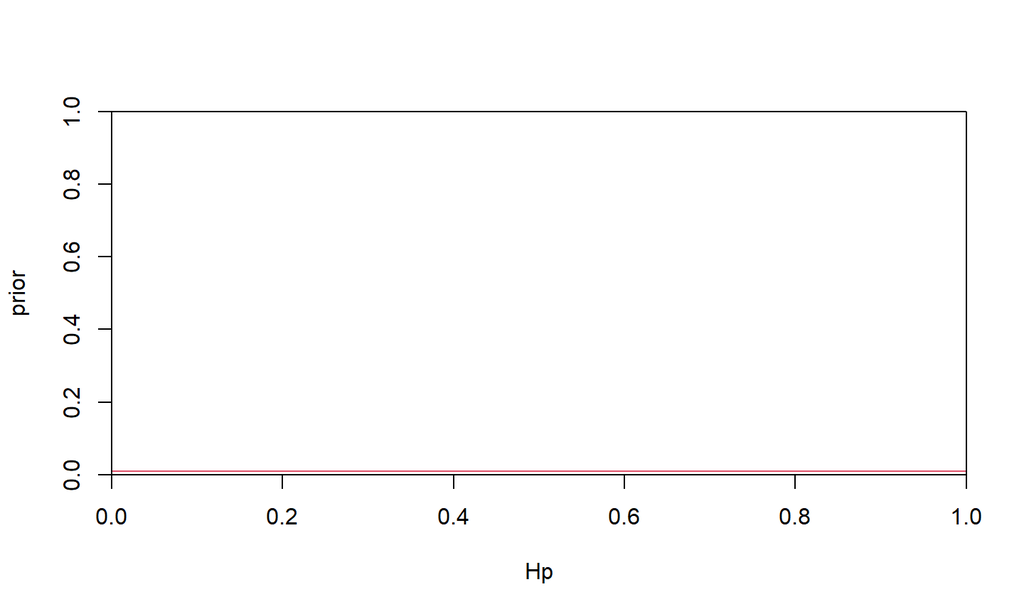

You are no longer in the realm of discrete hypothesis

## Continuum of hypotheses

```r
prior<-rep(1,length(Hp))
```

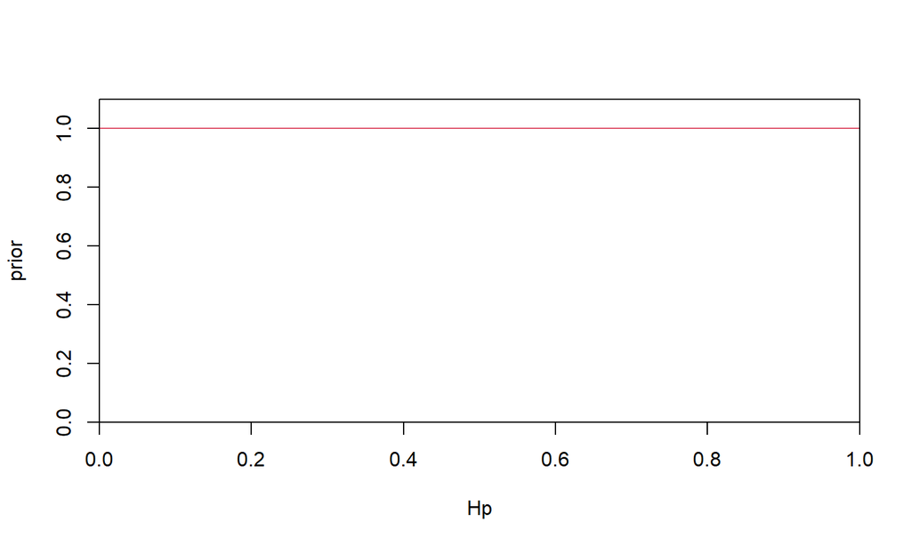

## likelihoods

```r
(l<-dbinom(3,4,Hp))
```

```
##   [1] 0.00000000 0.00000396 0.00003136 0.00010476 0.00024576 0.00047500
##   [7] 0.00081216 0.00127596 0.00188416 0.00265356 0.00360000 0.00473836
##  [13] 0.00608256 0.00764556 0.00943936 0.01147500 0.01376256 0.01631116
##  [19] 0.01912896 0.02222316 0.02560000 0.02926476 0.03322176 0.03747436
##  [25] 0.04202496 0.04687500 0.05202496 0.05747436 0.06322176 0.06926476
##  [31] 0.07560000 0.08222316 0.08912896 0.09631116 0.10376256 0.11147500
##  [37] 0.11943936 0.12764556 0.13608256 0.14473836 0.15360000 0.16265356
##  [43] 0.17188416 0.18127596 0.19081216 0.20047500 0.21024576 0.22010476
##  [49] 0.23003136 0.24000396 0.25000000 0.25999596 0.26996736 0.27988876
##  [55] 0.28973376 0.29947500 0.30908416 0.31853196 0.32778816 0.33682156
##  [61] 0.34560000 0.35409036 0.36225856 0.37006956 0.37748736 0.38447500
##  [67] 0.39099456 0.39700716 0.40247296 0.40735116 0.41160000 0.41517676
##  [73] 0.41803776 0.42013836 0.42143296 0.42187500 0.42141696 0.42001036
##  [79] 0.41760576 0.41415276 0.40960000 0.40389516 0.39698496 0.38881516
##  [85] 0.37933056 0.36847500 0.35619136 0.34242156 0.32710656 0.31018636
##  [91] 0.29160000 0.27128556 0.24918016 0.22521996 0.19934016 0.17147500
##  [97] 0.14155776 0.10952076 0.07529536 0.03881196 0.00000000
```

## Good job

Notice that since there are both heads and tails, the likelihoods of the extreme hypotheses (p=0 and p=1) is perfect 0

## The numerators

products of data likelihood times the prior probabilities

```r
(numerators<-l*prior)
```

```
##   [1] 0.00000000 0.00000396 0.00003136 0.00010476 0.00024576 0.00047500
##   [7] 0.00081216 0.00127596 0.00188416 0.00265356 0.00360000 0.00473836
##  [13] 0.00608256 0.00764556 0.00943936 0.01147500 0.01376256 0.01631116
##  [19] 0.01912896 0.02222316 0.02560000 0.02926476 0.03322176 0.03747436
##  [25] 0.04202496 0.04687500 0.05202496 0.05747436 0.06322176 0.06926476
##  [31] 0.07560000 0.08222316 0.08912896 0.09631116 0.10376256 0.11147500
##  [37] 0.11943936 0.12764556 0.13608256 0.14473836 0.15360000 0.16265356
##  [43] 0.17188416 0.18127596 0.19081216 0.20047500 0.21024576 0.22010476
##  [49] 0.23003136 0.24000396 0.25000000 0.25999596 0.26996736 0.27988876
##  [55] 0.28973376 0.29947500 0.30908416 0.31853196 0.32778816 0.33682156
##  [61] 0.34560000 0.35409036 0.36225856 0.37006956 0.37748736 0.38447500
##  [67] 0.39099456 0.39700716 0.40247296 0.40735116 0.41160000 0.41517676
##  [73] 0.41803776 0.42013836 0.42143296 0.42187500 0.42141696 0.42001036
##  [79] 0.41760576 0.41415276 0.40960000 0.40389516 0.39698496 0.38881516
##  [85] 0.37933056 0.36847500 0.35619136 0.34242156 0.32710656 0.31018636
##  [91] 0.29160000 0.27128556 0.24918016 0.22521996 0.19934016 0.17147500
##  [97] 0.14155776 0.10952076 0.07529536 0.03881196 0.00000000
```

```r
sum(numerators)
```

```
## [1] 19.99667
```

## Numerators do not sum up to 1 (neither do likelihoods)

divide

```r
(post<-numerators/sum(numerators))
```

```
##   [1] 0.000000e+00 1.980330e-07 1.568261e-06 5.238873e-06 1.229005e-05
##   [6] 2.375396e-05 4.061477e-05 6.380863e-05 9.422370e-05 1.327001e-04
##  [11] 1.800300e-04 2.369575e-04 3.041787e-04 3.823417e-04 4.720467e-04
##  [16] 5.738456e-04 6.882427e-04 8.156939e-04 9.566074e-04 1.111343e-03
##  [21] 1.280213e-03 1.463482e-03 1.661365e-03 1.874030e-03 2.101598e-03
##  [26] 2.344141e-03 2.601682e-03 2.874197e-03 3.161615e-03 3.463815e-03
##  [31] 3.780630e-03 4.111843e-03 4.457191e-03 4.816361e-03 5.188993e-03
##  [36] 5.574679e-03 5.972963e-03 6.383342e-03 6.805262e-03 7.238124e-03
##  [41] 7.681280e-03 8.134034e-03 8.595641e-03 9.065309e-03 9.542198e-03
##  [46] 1.002542e-02 1.051404e-02 1.100707e-02 1.150349e-02 1.200220e-02
##  [51] 1.250208e-02 1.300196e-02 1.350062e-02 1.399677e-02 1.448910e-02
##  [56] 1.497625e-02 1.545678e-02 1.592925e-02 1.639214e-02 1.684389e-02
##  [61] 1.728288e-02 1.770747e-02 1.811595e-02 1.850656e-02 1.887751e-02
##  [66] 1.922695e-02 1.955299e-02 1.985367e-02 2.012700e-02 2.037095e-02
##  [71] 2.058343e-02 2.076230e-02 2.090537e-02 2.101042e-02 2.107516e-02
##  [76] 2.109727e-02 2.107436e-02 2.100402e-02 2.088377e-02 2.071109e-02
##  [81] 2.048341e-02 2.019812e-02 1.985256e-02 1.944400e-02 1.896969e-02
##  [86] 1.842682e-02 1.781254e-02 1.712393e-02 1.635805e-02 1.551190e-02
##  [91] 1.458243e-02 1.356654e-02 1.246108e-02 1.126288e-02 9.968669e-03
##  [96] 8.575179e-03 7.079068e-03 5.476951e-03 3.765396e-03 1.940921e-03
## [101] 0.000000e+00
```

## There is your graphical representation of the continuum

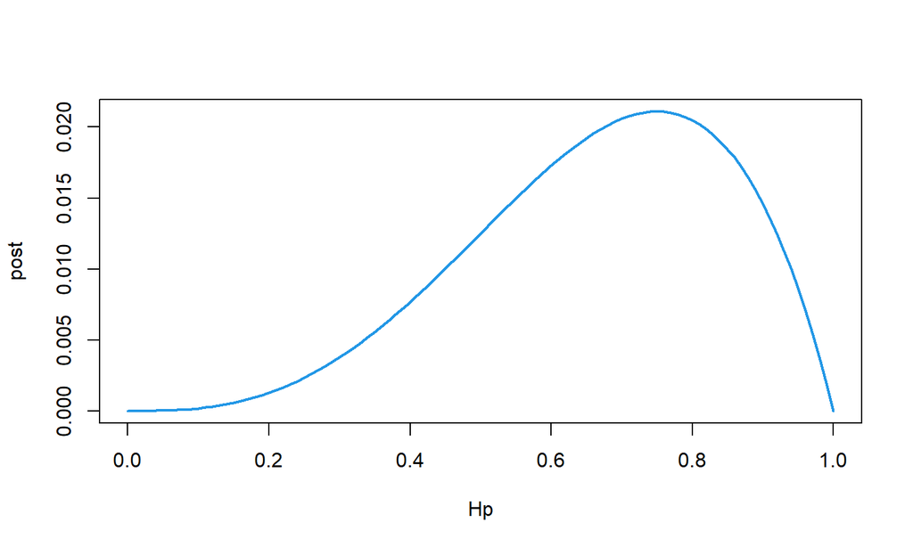

```r
plot(Hp,post,type="l",lwd=2,col=4)
```

## We named it post for posterior

but remember that every posterior can become prior of the next round.

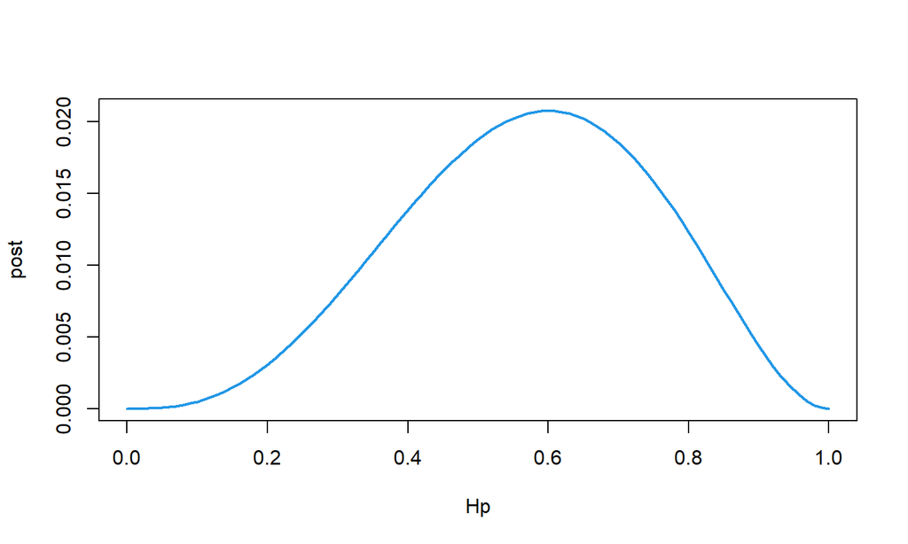

```r
post<-(dbinom(0,1,Hp)*post)/sum((dbinom(0,1,Hp)*post))
plot(Hp,post,type="l",lwd=2,col=4)
```

## The peak is at the observed proportion

since we started from the perfectly flat prior

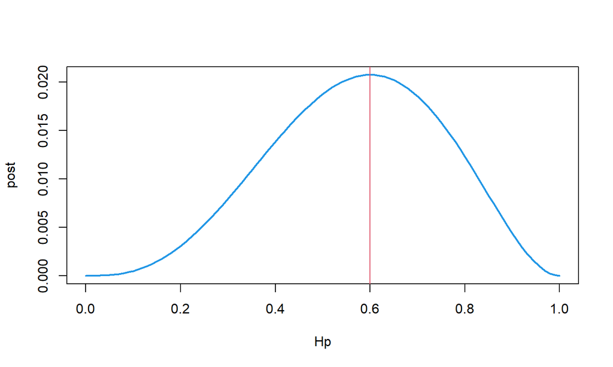

```r
plot(Hp,post,type="l",lwd=2,col=4)
abline(v=3/5,col=2)
```

## Is this the end?

It might be for simple systems with low number of parameters. This technique is called Grid approximation. But imagine you had some system that - unlike coin - has more than one parameter.

## Some examples from the audience.

## My example

Dice that has six sides: 1,2,3,4,5,6 and there are all sorts of probabilites as you can imagine. Fair

```r
rep(1/6,6)
```

```
## [1] 0.1666667 0.1666667 0.1666667 0.1666667 0.1666667 0.1666667
```

## Unfair dice might be

```r
(6:1)/sum(6:1)
```

```
## [1] 0.28571429 0.23809524 0.19047619 0.14285714 0.09523810 0.04761905
```

But there are many more.